# Biostat 203B Homework 2

Due Feb 7 @ 11:59PM

Yuetong Lyu

Use tidyverse (ggpot2, dplyr) to explore the [MIMIC-III](https://mimic.physionet.org) data introduced in [homework 1](https://ucla-biostat203b-2020winter.github.io/hw/hw1/hw1.html).

## Q1

Demographic information of the patients admitted into hospital is available in `ADMISSION.csv`. See https://mimic.physionet.org/mimictables/admissions/ for details of each field in this file. Summarize following variables using appropriate graphs:

- admission year
- admission month
- admission week day
- admission hour
- length of hospital stay
- admission type
- number of admissions per patient
- admission location
- insurance
- language
- religion
- martial status
- ethnicity
- death

Note it is possible that one patient (uniquely identified by the `SUBJECT_ID`) is admitted into hospital multiple times. When summarizing some demographic information, it makes sense to summarize based on only unique patients.

**Solution**

### Prerequisites

Load tidyverse and lubridate:

```r
library(tidyverse)
library(lubridate)
```

### Import data

First, try to parse the data:

```r
admission <- read_csv("/home/203bdata/mimic-iii/ADMISSIONS.csv")
admission %>% print(width = Inf)
```

```
## # A tibble: 58,976 x 19
##    ROW_ID SUBJECT_ID HADM_ID ADMITTIME           DISCHTIME
##     <dbl>      <dbl>   <dbl> <dttm>              <dttm>
##  1     21         22  165315 2196-04-09 12:26:00 2196-04-10 15:54:00
##  2     22         23  152223 2153-09-03 07:15:00 2153-09-08 19:10:00
##  3     23         23  124321 2157-10-18 19:34:00 2157-10-25 14:00:00
##  4     24         24  161859 2139-06-06 16:14:00 2139-06-09 12:48:00
##  5     25         25  129635 2160-11-02 02:06:00 2160-11-05 14:55:00
##  6     26         26  197661 2126-05-06 15:16:00 2126-05-13 15:00:00
##  7     27         27  134931 2191-11-30 22:16:00 2191-12-03 14:45:00
##  8     28         28  162569 2177-09-01 07:15:00 2177-09-06 16:00:00
##  9     29         30  104557 2172-10-14 14:17:00 2172-10-19 14:37:00
## 10     30         31  128652 2108-08-22 23:27:00 2108-08-30 15:00:00
##    DEATHTIME           ADMISSION_TYPE ADMISSION_LOCATION
##    <dttm>              <chr>          <chr>
```

[output cut: 59 more lines]

Everything looks fine except that I’d like to enforce ‘ROW_ID’, ‘SUBJECT_ID’, ‘HADM_ID’, to be `<int>` and ‘HOSPITAL_EXPIRE_FLAG’ and ‘HAS_CHARTEVENTS_DATA’ to be `<lgl>`:

```r
admission <- read_csv("/home/203bdata/mimic-iii/ADMISSIONS.csv",
                      col_types = cols(ROW_ID = col_integer(),
                                       SUBJECT_ID = col_integer(),
                                       HADM_ID = col_integer(),
                                       HOSPITAL_EXPIRE_FLAG = col_logical(),
                                       HAS_CHARTEVENTS_DATA = col_logical()))
admission %>% print(width = Inf)
```

```
## # A tibble: 58,976 x 19
##    ROW_ID SUBJECT_ID HADM_ID ADMITTIME           DISCHTIME
##     <int>      <int>   <int> <dttm>              <dttm>
##  1     21         22  165315 2196-04-09 12:26:00 2196-04-10 15:54:00
##  2     22         23  152223 2153-09-03 07:15:00 2153-09-08 19:10:00
##  3     23         23  124321 2157-10-18 19:34:00 2157-10-25 14:00:00
##  4     24         24  161859 2139-06-06 16:14:00 2139-06-09 12:48:00
##  5     25         25  129635 2160-11-02 02:06:00 2160-11-05 14:55:00
##  6     26         26  197661 2126-05-06 15:16:00 2126-05-13 15:00:00
##  7     27         27  134931 2191-11-30 22:16:00 2191-12-03 14:45:00
##  8     28         28  162569 2177-09-01 07:15:00 2177-09-06 16:00:00
##  9     29         30  104557 2172-10-14 14:17:00 2172-10-19 14:37:00
## 10     30         31  128652 2108-08-22 23:27:00 2108-08-30 15:00:00
##    DEATHTIME           ADMISSION_TYPE ADMISSION_LOCATION
##    <dttm>              <chr>          <chr>
```

[output cut: 59 more lines]

### Admission Time

I’d like to examine if there is any pattern in the admission time. Visualize how the number of hospital admissions changes over year.

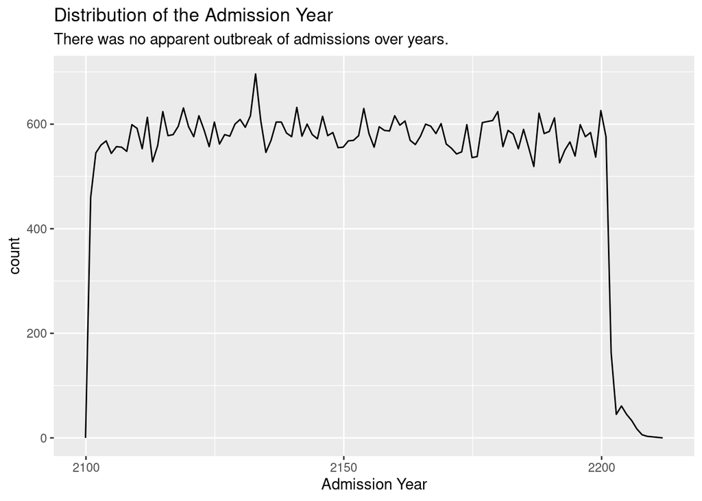

```r
admission %>%
  ggplot(aes(x = ADMITTIME)) +
  geom_freqpoly(binwidth = 31536000) + # 86400 seconds = a day
  labs(x = "Admission Year",
       title = "Distribution of the Admission Year",
       subtitle = "There was no apparent outbreak of admissions over years.")
```

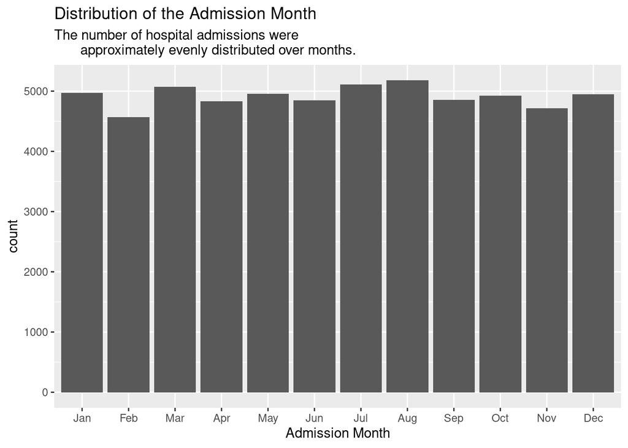

```r
admission %>%
  mutate(adm_month = month(ADMITTIME, label = TRUE)) %>%
  ggplot(aes(x = adm_month)) +
  geom_bar() +
  labs(x = "Admission Month",
       title = "Distribution of the Admission Month",
       subtitle = "The number of hospital admissions were
       approximately evenly distributed over months.")
```

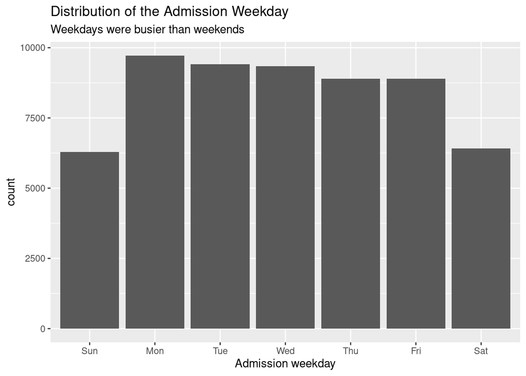

```r
admission %>%
  mutate(adm_wday = wday(ADMITTIME, label = TRUE)) %>%
  ggplot(aes(x = adm_wday)) +
  geom_bar() +
  labs(x = "Admission weekday",
       title = "Distribution of the Admission Weekday",
       subtitle = "Weekdays were busier than weekends")
```

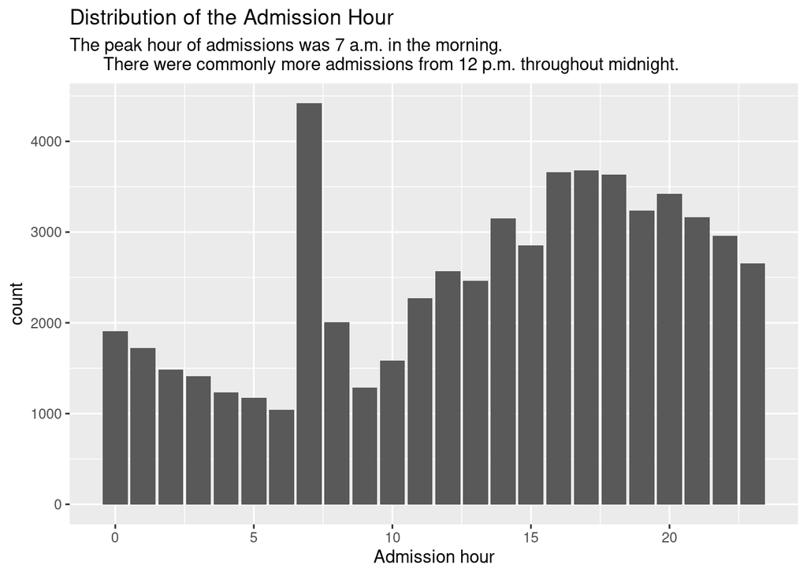

```r
admission %>%
  mutate(adm_hour = hour(ADMITTIME)) %>%
  ggplot(aes(x = adm_hour)) +
  geom_bar() +
  labs(x = "Admission hour",
       title = "Distribution of the Admission Hour",
       subtitle = "The peak hour of admissions was 7 a.m. in the morning.
       There were commonly more admissions from 12 p.m. throughout midnight. ")
```

Why those peaks?

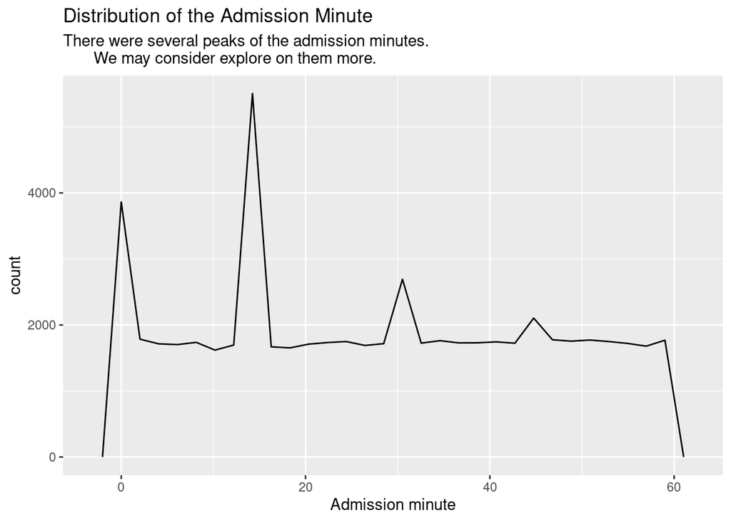

```r
admission %>%
  mutate(adm_min = minute(ADMITTIME)) %>%
  ggplot(aes(x = adm_min)) +
  geom_freqpoly() +
  labs(x = "Admission minute", title = "Distribution of the Admission Minute",
       subtitle = "There were several peaks of the admission minutes.
       We may consider explore on them more.")
```

### Length of Hospital Stay

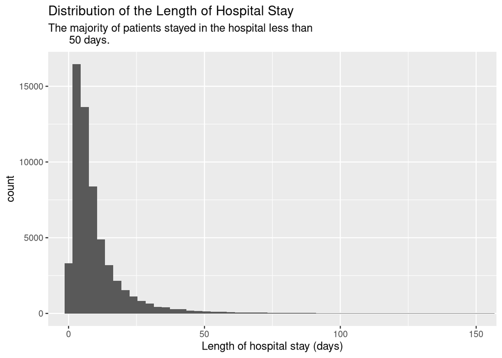

```r
admission %>%
  mutate(los_days = as.numeric(as.duration(DISCHTIME - ADMITTIME) / 86400)) %>%
  ggplot(aes(x = los_days)) +
  coord_cartesian(xlim = c(0, 150)) +
  geom_histogram(bins = 100) +
  labs(x = "Length of hospital stay (days)",
       title = "Distribution of the Length of Hospital Stay",
       subtitle = "The majority of patients stayed in the hospital less than
       50 days.")
```

### Admission Type

What admission types are there?

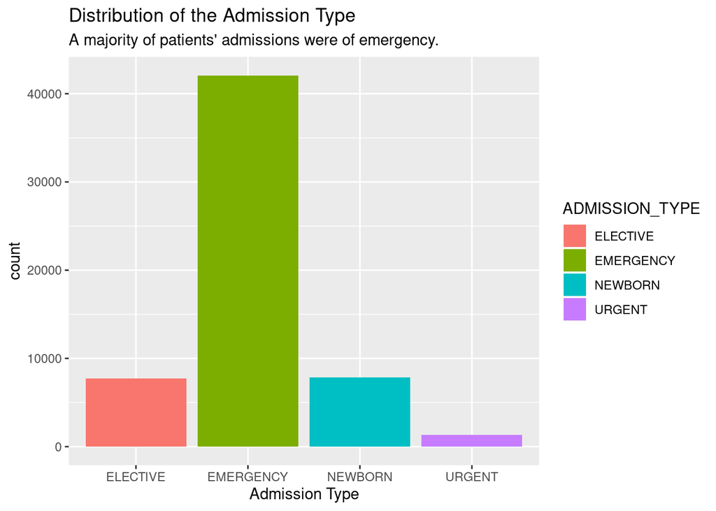

```r
admission %>%
  ggplot() +
  geom_bar(mapping = aes(x = ADMISSION_TYPE, fill = ADMISSION_TYPE)) +
  labs(x = "Admission Type", title = "Distribution of the Admission Type",
       subtitle = "A majority of patients' admissions were of emergency.")
```

### Number of Admissions Per Patient

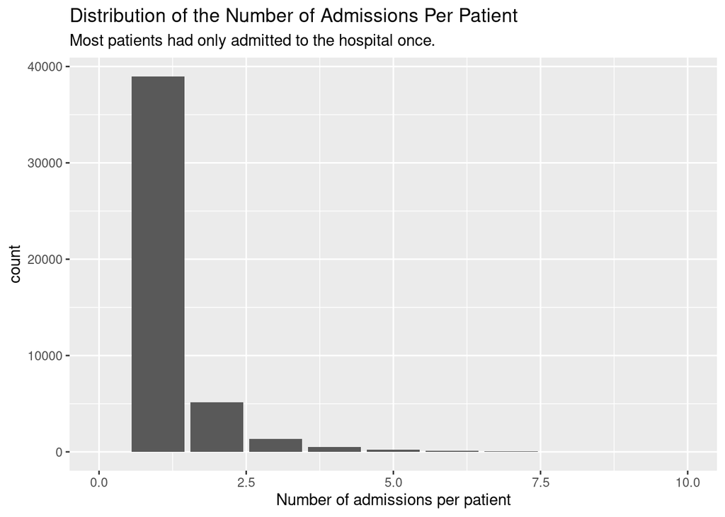

```r
admission %>%
  group_by(SUBJECT_ID) %>%
  summarise(counts = n()) %>%
  ggplot() +
  coord_cartesian(xlim = c(0, 10)) +
  geom_bar(mapping = aes(x = counts)) +
  labs(x = "Number of admissions per patient",
       title = "Distribution of the Number of Admissions Per Patient",
       subtitle = "Most patients had only admitted to the hospital once.")
```

### Admission Location

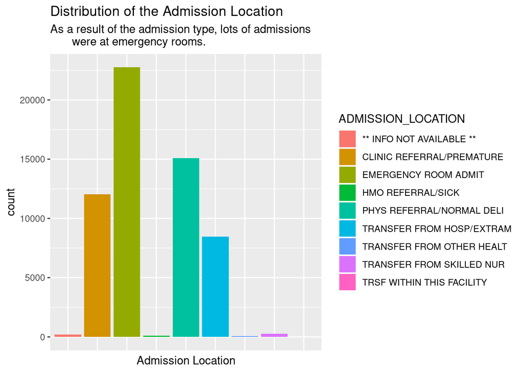

```r
admission %>%
  ggplot() +
  geom_bar(mapping = aes(x = ADMISSION_LOCATION, fill = ADMISSION_LOCATION)) +
  labs(x = "Admission Location",
       title = "Distribution of the Admission Location",
       subtitle = "As a result of the admission type, lots of admissions
       were at emergency rooms.") +
  theme(axis.text.x=element_blank(),
        axis.ticks.x=element_blank())
```

### Insurance, Language, Religion, Marital Status and Ethnicity

For those variables, I will summarize them based on unique patients.

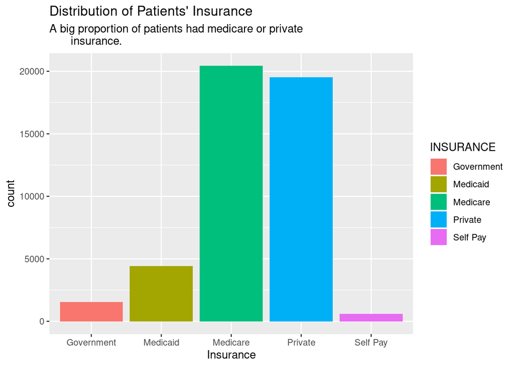

```r
admission %>%
  distinct(SUBJECT_ID, .keep_all = TRUE) %>%
  ggplot() +
  geom_bar(mapping = aes(x = INSURANCE, fill = INSURANCE)) +
  labs(x = "Insurance",
       title = "Distribution of Patients' Insurance",
       subtitle = "A big proportion of patients had medicare or private
       insurance.")
```

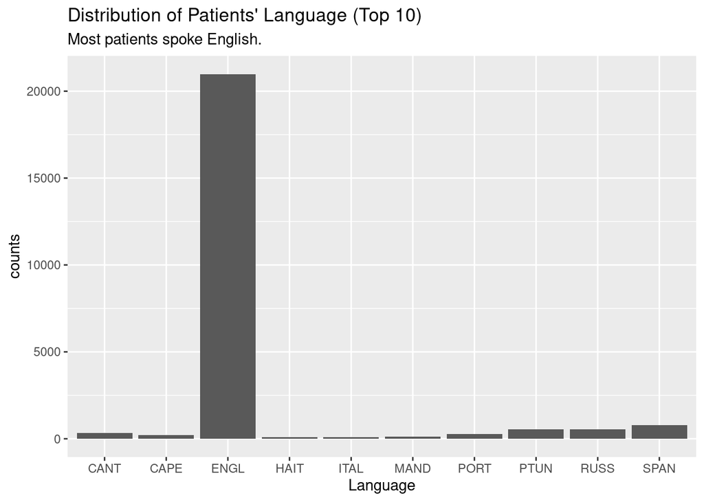

```r
admission %>%
  distinct(SUBJECT_ID, .keep_all = TRUE) %>%
  group_by(LANGUAGE) %>%
  summarise(counts = n()) %>%
  arrange(desc(counts)) %>%
  slice(2:11) %>%
  ggplot(., aes(x = LANGUAGE, y = counts)) +
  geom_bar(stat = 'identity') +
  labs(x = "Language",
       title = "Distribution of Patients' Language (Top 10)",
       subtitle = "Most patients spoke English.")
```

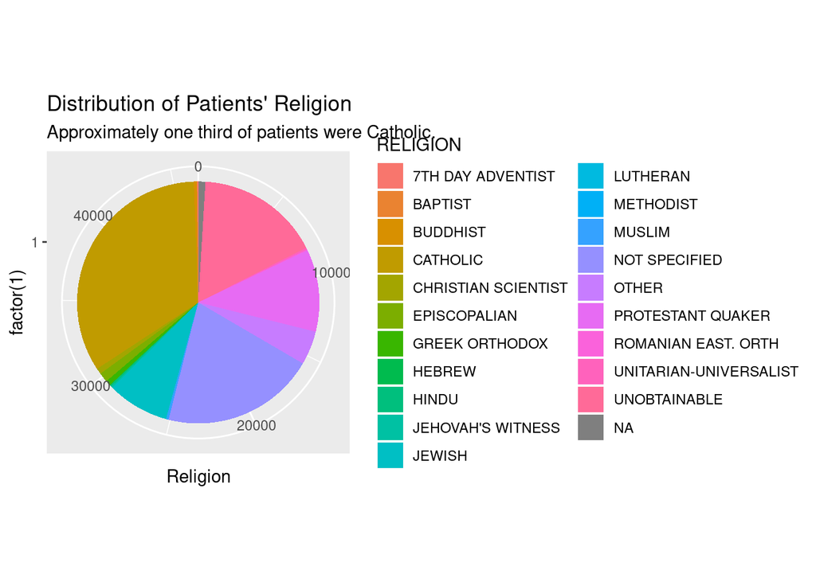

```r
admission %>%
  distinct(SUBJECT_ID, .keep_all = TRUE) %>%
  ggplot(mapping = aes(x = factor(1), fill = RELIGION)) +
  geom_bar(width = 1) +
  coord_polar("y") +
  labs(y = "Religion",
       title = "Distribution of Patients' Religion",
       subtitle = "Approximately one third of patients were Catholic.")
```

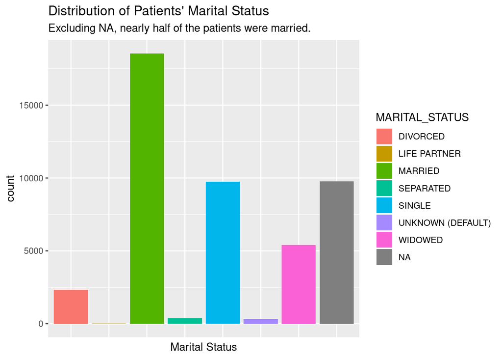

```r
admission %>%
  distinct(SUBJECT_ID, .keep_all = TRUE) %>%
  ggplot() +
  geom_bar(mapping = aes(x = MARITAL_STATUS, fill = MARITAL_STATUS)) +
  labs(x = "Marital Status",
       title = "Distribution of Patients' Marital Status",
       subtitle = "Excluding NA, nearly half of the patients were married.") +
  theme(axis.text.x=element_blank(),
        axis.ticks.x=element_blank())
```

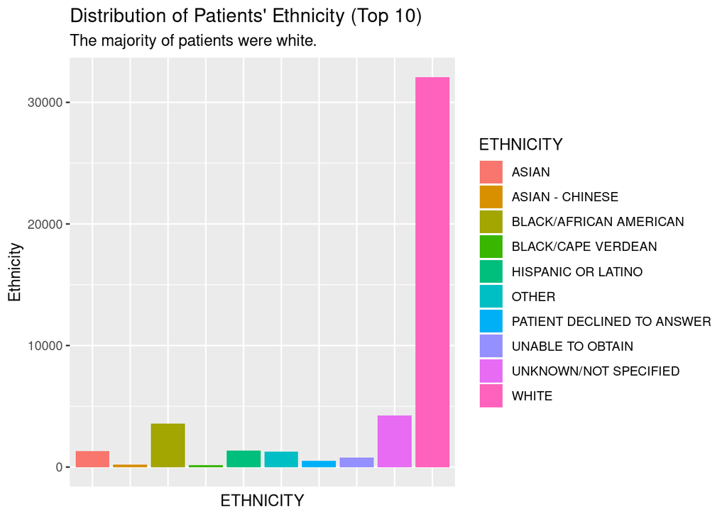

```r
admission %>%
  distinct(SUBJECT_ID, .keep_all = TRUE) %>%
  group_by(ETHNICITY) %>%
  summarise(counts = n()) %>%
  arrange(desc(counts)) %>%
  top_n(10) %>%
  ggplot(., aes(x = ETHNICITY, y = counts, fill = ETHNICITY)) +
  geom_bar(stat = 'identity') +
  theme(axis.text.x=element_blank(),
        axis.ticks.x=element_blank()) +
  labs(y = "Ethnicity",
       title = "Distribution of Patients' Ethnicity (Top 10)",
       subtitle = "The majority of patients were white.")
```

### Death

We should also summarise this variable based on unique patients.

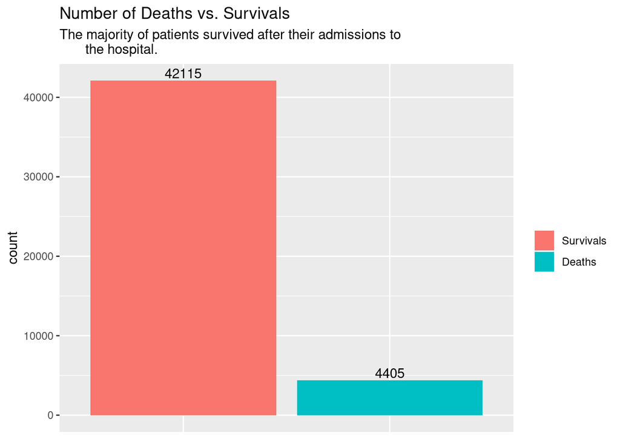

```r
admission %>%
  distinct(SUBJECT_ID, .keep_all = TRUE) %>%
  ggplot(mapping = aes(x = HOSPITAL_EXPIRE_FLAG,
                       fill = HOSPITAL_EXPIRE_FLAG)) +
  geom_bar() +
  scale_fill_discrete(name = NULL, labels = c("Survivals", "Deaths")) +
  theme(axis.text.x=element_blank(),
        axis.ticks.x=element_blank(),
        axis.title.x=element_blank()) +
  geom_text(stat = 'count', aes(label = ..count.., vjust = -0.2)) +
  labs(title = "Number of Deaths vs. Survivals",
       subtitle = "The majority of patients survived after their admissions to
       the hospital.")
```